# 📝 NumPy Assignment

This assignment covers basics of NumPy arrays, array creation, arithmetic operations, and aggregations.

## 📌 Section 1: Creating Arrays

### Q1. Create a **1D NumPy array** of integers from 10 to 19 (inclusive).

```python
import numpy as np

arr_1d = np.arange(10, 20)
arr_1d
```

```
array([10, 11, 12, 13, 14, 15, 16, 17, 18, 19])
```

### Q2. Create a **2D NumPy array** of shape (3, 4) with all elements as float `7.5`.

```python
arr_2d = np.full((3, 4), 7.5, dtype=float)
arr_2d
```

```
array([[7.5, 7.5, 7.5, 7.5],
       [7.5, 7.5, 7.5, 7.5],
       [7.5, 7.5, 7.5, 7.5]])
```

### Q3. Create a **3D NumPy array** of shape (2, 3, 4) filled with random integers between 0 and 9.

```python
arr_3d = np.random.randint(0, 10, size=(2, 3, 4))
arr_3d
```

```
array([[[4, 9, 0, 6],
        [7, 5, 9, 8],
        [3, 9, 3, 5]],

       [[2, 7, 4, 2],
        [9, 2, 7, 8],
        [1, 1, 5, 5]]])
```

### Q4. Create a **6D NumPy array** with shape `(1,2,1,2,1,2)` filled with zeros.

```python
# arr_6d = np.zeros((2,3,4,2,1), dtype=int)
# arr_6d
```

```python
arr_6d = np.zeros((1, 2, 1, 2, 1, 2), dtype=int)
arr_6d.shape, arr_6d
```

```
((1, 2, 1, 2, 1, 2),
 array([[[[[[0, 0]],

           [[0, 0]]]],



         [[[[0, 0]],

           [[0, 0]]]]]]))
```

## 📌 Section 2: Array Creation Functions

### Q5. Use `np.zeros` and `np.reshape` to create a **4x3 matrix** of zeros.

```python
arr_zeros = np.zeros(12).reshape(4, 3)
arr_zeros
```

```
array([[0., 0., 0.],
       [0., 0., 0.],
       [0., 0., 0.],
       [0., 0., 0.]])
```

### Q6. Use `np.arange` and `np.reshape` to create a **3x3 matrix** of numbers from 1 to 9.

```python
arr_arange = np.arange(1, 10).reshape(3, 3)
arr_arange
```

```
array([[1, 2, 3],
       [4, 5, 6],
       [7, 8, 9]])
```

### Q7. Create a **1D array of 5 ones** with data type `int32`.

```python
arr_ones = np.ones(5, dtype=np.int32)
arr_ones
```

```
array([1, 1, 1, 1, 1])
```

### Q8. Combine `np.arange` and `np.reshape` to create a **3D array** of shape `(2,2,3)` containing numbers from 1 to 12.

```python
arr_3d = np.arange(1, 13).reshape(2, 2, 3)
arr_3d
```

```
array([[[ 1,  2,  3],
        [ 4,  5,  6]],

       [[ 7,  8,  9],
        [10, 11, 12]]])
```

## 📌 Section 3: Arithmetic Operations

### Q9. Create two 1D arrays `a=[1,2,3]` and `b=[4,5,6]`. Perform **addition, subtraction, multiplication, and division**.

```python
a = np.array([1,2,3])
b = np.array([4,5,6])

add = a + b
sub = a - b
mul = a * b
div = a / b

add, sub, mul, div
```

```
(array([5, 7, 9]),
 array([-3, -3, -3]),
 array([ 4, 10, 18]),
 array([0.25, 0.4 , 0.5 ]))
```

### Q10. Multiply every element of the array `[2, 4, 6, 8]` by `3`.

```python
arr = np.array([2, 4, 6, 8])
arr_times_3 = arr * 3
arr_times_3
```

```
array([ 6, 12, 18, 24])
```

## 📌 Section 4: Aggregation Functions

### Q11. Given an array `x = np.array([5, 10, 15, 20, 25])`, find the **sum, mean, max, and min**.

```python
x = np.array([5, 10, 15, 20, 25])

total = x.sum()
avg = x.mean()
maximum = x.max()
minimum = x.min()

total, avg, maximum, minimum
```

```
(75, 15.0, 25, 5)
```

### Q12. Create a **3x3 matrix** with values from 1 to 9 and find the **row-wise sum and column-wise mean**.

```python
arr = np.arange(1, 10).reshape(3, 3)

row_sum = arr.sum(axis=1)
col_mean = arr.mean(axis=0)

arr,row_sum, col_mean
```

```
(array([[1, 2, 3],
        [4, 5, 6],
        [7, 8, 9]]),
 array([ 6, 15, 24]),
 array([4., 5., 6.]))
```

## 📌 Section 5: For Loop Practice

### Q13. Use a **for loop** to create a list of squares of numbers from 1 to 10.

```python
squares = []
for i in range(1, 11):
    squares.append(i**2)

squares
```

```
[1, 4, 9, 16, 25, 36, 49, 64, 81, 100]
```

### Q14. Use a **for loop** to create a DataFrame with two columns:

- `Number` → values from 1 to 5
- `Square` → square of each number

```python
import pandas as pd

numbers = []
squares = []

for i in range(1, 6):
    numbers.append(i)
    squares.append(i**2)

df = pd.DataFrame({"Number": numbers, "Square": squares})
df
```

|  | Number | Square |
| --- | --- | --- |
| 0 | 1 | 1 |
| 1 | 2 | 4 |
| 2 | 3 | 9 |
| 3 | 4 | 16 |
| 4 | 5 | 25 |

## 📌 Section 6: Looping Forward and Backward Through Columns

### Q15. Loop **forward** through the columns `["A", "B", "C"]`, assign values `1, 2, 3` respectively, and create a DataFrame with 1 row.

```python
import pandas as pd

cols = ["A", "B", "C"]
values = [1, 2, 3]
data = {}

for i in range(len(cols)):   # forward loop
    data[cols[i]] = [values[i]]

df_forward = pd.DataFrame(data)
df_forward
```

|  | A | B | C |
| --- | --- | --- | --- |
| 0 | 1 | 2 | 3 |

### Q16. Loop **forward** through numbers 1 to 5, create columns `Col1` to `Col5`, and assign each column its square values for rows 1 to 5.

```python
cols = []
data = {}

for i in range(1, 6):   # forward loop
    col_name = f"Col{i}"
    cols.append(col_name)
    data[col_name] = [j**2 for j in range(1, 6)]

df_forward_multi = pd.DataFrame(data)
df_forward_multi
```

|  | Col1 | Col2 | Col3 | Col4 | Col5 |
| --- | --- | --- | --- | --- | --- |
| 0 | 1 | 1 | 1 | 1 | 1 |
| 1 | 4 | 4 | 4 | 4 | 4 |
| 2 | 9 | 9 | 9 | 9 | 9 |
| 3 | 16 | 16 | 16 | 16 | 16 |
| 4 | 25 | 25 | 25 | 25 | 25 |

### Q17. Loop **backward** through the columns `["X", "Y", "Z"]`, assign values `10, 20, 30` respectively, and create a DataFrame with 1 row.

```python
cols = ["X", "Y", "Z"]
values = [10, 20, 30]
data = {}

for i in range(len(cols)-1, -1, -1):   # backward loop
    data[cols[i]] = [values[i]]

df_backward = pd.DataFrame(data)
df_backward
```

|  | Z | Y | X |
| --- | --- | --- | --- |
| 0 | 30 | 20 | 10 |

### Q18. Loop **backward** through numbers 1 to 4, create columns `C4, C3, C2, C1`, and assign each column values `[1,2,3,4]`.

```python
cols = []
data = {}

for i in range(4, 0, -1):   # backward loop
    col_name = f"C{i}"
    cols.append(col_name)
    data[col_name] = [1, 2, 3, 4]

df_backward_multi = pd.DataFrame(data)
df_backward_multi
```

|  | C4 | C3 | C2 | C1 |
| --- | --- | --- | --- | --- |
| 0 | 1 | 1 | 1 | 1 |
| 1 | 2 | 2 | 2 | 2 |
| 2 | 3 | 3 | 3 | 3 |
| 3 | 4 | 4 | 4 | 4 |

## 📌 Section 8: Word Problems Using Loops

### Q21. SUM OF ALL EVEN NUMBERS FROM 1 TO 50

Write a Python program to calculate the **sum of all even numbers** from 1 to 50 using a `for` loop.

```python
total = 0
for i in range(1, 51):
    if i % 2 == 0:
        total += i
total
```

```
650
```

### Q22. PRINT MULTIPLICATION TABLE OF 7

Write a Python program to **print the multiplication table of 7** from 1 to 10 using a `for` loop.

```python
for i in range(1, 11):
    print(f"7 x {i} = {7*i}")
```

```
7 x 1 = 7
7 x 2 = 14
7 x 3 = 21
7 x 4 = 28
7 x 5 = 35
7 x 6 = 42
7 x 7 = 49
7 x 8 = 56
7 x 9 = 63
7 x 10 = 70
```

### Q23. CALCULATE FACTORIAL OF A NUMBER

Write a Python program to calculate the **factorial of 6** using a `for` loop.

```python
n = 6
factorial = 1
for i in range(1, n+1):
    factorial *= i
factorial
```

```
720
```

```python
fact = 1
for i in range(6,0,-1):
    fact = fact * i
fact
```

```
720
```

### Q24. COUNT OCCURRENCES OF EACH CHARACTER IN A STRING

Given the string `"python loops"`, write a Python program to **count the occurrence of each character** using a `for` loop.

```python
text = "python loops"
char_count = {}

for char in text:
    if char in char_count:
        char_count[char] += 1
    else:
        char_count[char] = 1

char_count
```

```
{'p': 2, 'y': 1, 't': 1, 'h': 1, 'o': 3, 'n': 1, ' ': 1, 'l': 1, 's': 1}
```

## 📌 Section 9: Intermediate Computation Using Loops

### Q25. FOR LOOP: CALCULATE FIBONACCI SERIES UP TO N TERMS

Write a Python program to generate the **first 10 terms of the Fibonacci series** using a `for` loop.

```python
n = 10
fib_series = [0, 1]

for i in range(2, n):
    next_term = fib_series[i-1] + fib_series[i-2]
    fib_series.append(next_term)

fib_series
```

```
[0, 1, 1, 2, 3, 5, 8, 13, 21, 34]
```

### Q26. WHILE LOOP: SUM OF DIGITS OF A NUMBER

Write a Python program to calculate the **sum of digits of 58742** using a `while` loop.

```python
num = 58742
sum_digits = 0

while num > 0:
    digit = num % 10
    sum_digits += digit
    num = num // 10

sum_digits
```

```
26
```

## 📌 Section 10: Do-While and Do-Until Simulation

- Python doesn’t have built-in `do-while` or `do-until`, but we can simulate them using `while True` with a break condition.

### Q27. SIMULATE DO-WHILE LOOP: counting until a condition

```python
count = 0

while True:
    print(f"Iteration: {count}")
    count += 1

    if count >= 10:  # condition to exit
        break

print("Loop finished!")
```

```
Iteration: 0
Iteration: 1
Iteration: 2
Iteration: 3
Iteration: 4
Iteration: 5
Iteration: 6
Iteration: 7
Iteration: 8
Iteration: 9
Loop finished!
```

### Q28. SIMULATE DO-UNTIL LOOP: COUNTDOWN FROM 5 TO 1

Write a Python program to **print numbers from 5 down to 1** using a `do-until` style loop (execute loop at least once and stop when number < 1).

```python
# Simulating do-until loop in Python
n = 5
while True:
    print(n)
    n -= 1
    if n < 1:  # loop until n < 1
        break
```

```
5
4
3
2
1
```

✅ Explanation:

- **Do-while:** Executes the block at least once and repeats while the condition is true.
- **Do-until:** Executes the block at least once and repeats until the condition becomes true.

## 📌 Section 11: Special Statements – break, exit, pass

### Q29. USING `break`: FIND FIRST NUMBER DIVISIBLE BY 7 IN A LIST

Write a Python program to **find the first number divisible by 7** in the list `[10, 13, 20, 28, 35]` using a `for` loop and `break`.

```python
numbers = [10, 13, 20, 28, 35]

for num in numbers:
    if num % 7 == 0:
        first_div7 = num
        break

first_div7
```

```
28
```

### Q30. USING `exit()`: TERMINATE PROGRAM WHEN A NEGATIVE NUMBER IS FOUND IN A LIST

Write a Python program to **scan the list `[5, 8, 12, -3, 7]`** and terminate the program immediately using `exit()` if a negative number is found.

- uncomment this and run.

```python
# import sys

# numbers = [5, 8, 12, -3, 7]

# for n in numbers:
#     if n < 0:
#         sys.exit(f"Negative number {n} found. Program terminated.")
#     print(f"Number: {n}")
```

```python
# In notebooks, to avoid killing the kernel, you can catch the exit for demonstration:
import sys

numbers = [5, 8, -2, 7]

try:
    for n in numbers:
        if n < 0:
            sys.exit(f"Negative number {n} found. Program terminated.")
        print(n)
except SystemExit as e:
    print(f"Caught exit: {e}")

print("Notebook continues running!")
```

```
5
8
Caught exit: Negative number -2 found. Program terminated.
Notebook continues running!
```

### Q31. USING `pass`: SKIP SPECIFIC CONDITION IN LOOP

Write a Python program to **print numbers from 1 to 5** but **skip 3** using `pass`.

```python
for i in range(1, 6):
    if i == 3:
        pass  # placeholder, skip printing 3
    else:
        print(i)
```

```
1
2
4
5
```

```
✅ Key points:
- `break` → exits the nearest loop immediately.
- `exit()` → terminates the program completely.
- `pass` → acts as a placeholder, does nothing, allowing the program to continue.
```

## 📌 Section 12: Nested Loops

### Q32. NESTED FOR LOOPS: PRINT A PATTERN

Write a Python program to **print the following pattern** using nested `for` loops:

```
*
* *
* * *
* * * *
* * * * *
```

```python
rows = 5

for i in range(1, rows+1):
    for j in range(i):
        print("*", end=" ")
    print()
```

[output not shown]

### Q33. COMBINED FOR AND WHILE LOOPS: MULTIPLICATION TABLE OF 1 TO 3

Write a Python program using a **for loop** for numbers 1 to 3 and a **while loop** to print their multiplication table up to 5.

```python
for i in range(1, 4):
    j = 1
    print(f"Multiplication Table of {i}:")
    while j <= 5:
        print(f"{i} x {j} = {i*j}")
        j += 1
    print()
```

```
Multiplication Table of 1:
1 x 1 = 1
1 x 2 = 2
1 x 3 = 3
1 x 4 = 4
1 x 5 = 5

Multiplication Table of 2:
2 x 1 = 2
2 x 2 = 4
2 x 3 = 6
2 x 4 = 8
2 x 5 = 10

Multiplication Table of 3:
3 x 1 = 3
3 x 2 = 6
3 x 3 = 9
3 x 4 = 12
3 x 5 = 15
```

## 📌 Section 13: Broadcasted Addition

### Q34. ADD A 1D ARRAY TO EACH ROW OF A 2D ARRAY

Given a 2D array:

```python
arr_2d = np.array([[1, 2, 3],
                   [4, 5, 6],
                   [7, 8, 9]])
arr_1d = np.array([10, 20, 30])
```

Use **broadcasting** to add `arr_1d` to each row of `arr_2d`.

```python
result = arr_2d + arr_1d
result
```

```
array([[11, 22, 33],
       [14, 25, 36],
       [17, 28, 39]])
```

### Q35. ADD A COLUMN VECTOR TO EACH COLUMN OF A 2D ARRAY

Given a 2D array:

```python
arr_2d = np.array([[1, 2, 3],
                   [4, 5, 6],
                   [7, 8, 9]])
col_vec = np.array([[10],
                    [20],
                    [30]])
```

Use **broadcasting** to add `col_vec` to each column of `arr_2d`.

```python
result = arr_2d + col_vec
result
```

```
array([[11, 12, 13],
       [24, 25, 26],
       [37, 38, 39]])
```

## 📌 Section 14: Linear Algebra (Matrix Operations)

### Q36. MATRIX MULTIPLICATION

Given matrices:

```python
A = np.array([[1, 2],
              [3, 4]])
B = np.array([[5, 6],
              [7, 8]])
```

Compute the **matrix multiplication** $A \times B$.

```python
C = np.dot(A, B)
C
```

```
array([[19, 22],
       [43, 50]])
```

### Q37. DETERMINANT AND INVERSE OF A MATRIX

Given matrix:

```python
M = np.array([[2, 1],
              [5, 3]])
```

Calculate the **determinant** and **inverse** of `M`.

```python
det_M = np.linalg.det(M)
inv_M = np.linalg.inv(M)

det_M, inv_M
```

```
(1.0000000000000002,
 array([[ 3., -1.],
        [-5.,  2.]]))
```

## 📌 Section 15: Numerical Maniputlations

```python
import pandas as pd
from io import StringIO

# Create a CSV-like string with ':' delimiter and extra numeric columns
data = """NAME:GENDER:EDUCATION:SAS:R:PYTHON:SQL:EXCEL:AGE:YEARLY_SALARY
PREETAM:MALE:MBA:800::600:700:650:30:75000
RAJ:FEMALE:BTECH:700:800:500:400:300:28:68000
LAVLIN:MALE:BTECH:100:200::300:250:25:50000
ANITA:FEMALE:MCA::650:700:600:0:27:72000
KUMAR:MALE:MSC:500:550:600:450:400:32:80000
PRIYA:FEMALE:BTECH:600:700:750:500:450:26:70000
VIKRAM:MALE:MBA:750:800:700:650:600:31:78000
SUNITA:FEMALE:MCA:500:600:550:400:350:29:69000
RAHUL:MALE:BTECH:450:500:400:350:300:27:65000
MEERA:FEMALE:MSC:600:650:700:550:500:30:73000
"""

# Use StringIO to simulate reading from a file
df = pd.read_csv(StringIO(data), delimiter=':')

# Replace missing values
df = df.fillna('N/A')  # For character columns
df = df.replace('', 0)  # For numeric columns

# Convert appropriate columns to numeric
numeric_cols = ['SAS', 'R', 'PYTHON', 'SQL', 'EXCEL', 'AGE', 'YEARLY_SALARY']
df[numeric_cols] = df[numeric_cols].apply(pd.to_numeric, errors='coerce').fillna(0)

# Print the modified DataFrame
print("Modified DataFrame:")
print(df)
```

```
Modified DataFrame:
      NAME  GENDER EDUCATION    SAS      R  PYTHON  SQL  EXCEL  AGE  \
0  PREETAM    MALE       MBA  800.0    0.0   600.0  700    650   30
1      RAJ  FEMALE     BTECH  700.0  800.0   500.0  400    300   28
2   LAVLIN    MALE     BTECH  100.0  200.0     0.0  300    250   25
3    ANITA  FEMALE       MCA    0.0  650.0   700.0  600      0   27
4    KUMAR    MALE       MSC  500.0  550.0   600.0  450    400   32
5    PRIYA  FEMALE     BTECH  600.0  700.0   750.0  500    450   26
6   VIKRAM    MALE       MBA  750.0  800.0   700.0  650    600   31
7   SUNITA  FEMALE       MCA  500.0  600.0   550.0  400    350   29
8    RAHUL    MALE     BTECH  450.0  500.0   400.0  350    300   27
9    MEERA  FEMALE       MSC  600.0  650.0   700.0  550    500   30

   YEARLY_SALARY
0          75000
1          68000
2          50000
3          72000
4          80000
5          70000
6          78000
7          69000
8          65000
9          73000
```

### Questions & Answers:

#### Q1. Compute the **average score** for each student across SAS, R, PYTHON, SQL, and EXCEL.

```python
df['AVERAGE_SCORE'] = df[['SAS','R','PYTHON','SQL','EXCEL']].mean(axis=1)
df[['NAME','AVERAGE_SCORE']]
```

|  | NAME | AVERAGE_SCORE |
| --- | --- | --- |
| 0 | PREETAM | 550.0 |
| 1 | RAJ | 540.0 |
| 2 | LAVLIN | 170.0 |
| 3 | ANITA | 390.0 |
| 4 | KUMAR | 500.0 |
| 5 | PRIYA | 600.0 |
| 6 | VIKRAM | 700.0 |
| 7 | SUNITA | 480.0 |
| 8 | RAHUL | 400.0 |
| 9 | MEERA | 600.0 |

#### Q2. Find the **maximum and minimum yearly salary** among all employees.

```python
max_salary = df['YEARLY_SALARY'].max()
min_salary = df['YEARLY_SALARY'].min()
max_salary, min_salary
```

```
(80000, 50000)
```

#### Q3. Create a new column **TOTAL_SCORE** as the sum of all skills.

```python
df['TOTAL_SCORE'] = df[['SAS','R','PYTHON','SQL','EXCEL']].sum(axis=1)
df[['NAME','TOTAL_SCORE']]
```

|  | NAME | TOTAL_SCORE |
| --- | --- | --- |
| 0 | PREETAM | 2750.0 |
| 1 | RAJ | 2700.0 |
| 2 | LAVLIN | 850.0 |
| 3 | ANITA | 1950.0 |
| 4 | KUMAR | 2500.0 |
| 5 | PRIYA | 3000.0 |
| 6 | VIKRAM | 3500.0 |
| 7 | SUNITA | 2400.0 |
| 8 | RAHUL | 2000.0 |
| 9 | MEERA | 3000.0 |

#### Q4. Find the **name(s) of student(s) having TOTAL_SCORE greater than 3000**.

```python
high_scorers = df[df['TOTAL_SCORE'] > 3000]['NAME']
high_scorers
```

```
6    VIKRAM
Name: NAME, dtype: object
```

#### Q5. Calculate the **average age of employees who scored more than 600 in PYTHON**.

```python
avg_age = df[df['PYTHON'] > 600]['AGE'].mean()
avg_age
```

```
28.5
```

#### Q6. Replace any **0 values in numeric columns with the column mean**.

```python
for col in numeric_cols:
    mean_val = df[col].replace(0, pd.NA).mean()
    df[col] = df[col].replace(0, mean_val)

df
```

|  | NAME | GENDER | EDUCATION | SAS | R | PYTHON | SQL | EXCEL | AGE | YEARLY_SALARY | AVERAGE_SCORE | TOTAL_SCORE |
| --- | --- | --- | --- | --- | --- | --- | --- | --- | --- | --- | --- | --- |
| 0 | PREETAM | MALE | MBA | 800.000000 | 605.555556 | 600.000000 | 700 | 650.000000 | 30 | 75000 | 550.0 | 2750.0 |
| 1 | RAJ | FEMALE | BTECH | 700.000000 | 800.000000 | 500.000000 | 400 | 300.000000 | 28 | 68000 | 540.0 | 2700.0 |
| 2 | LAVLIN | MALE | BTECH | 100.000000 | 200.000000 | 611.111111 | 300 | 250.000000 | 25 | 50000 | 170.0 | 850.0 |
| 3 | ANITA | FEMALE | MCA | 555.555556 | 650.000000 | 700.000000 | 600 | 422.222222 | 27 | 72000 | 390.0 | 1950.0 |
| 4 | KUMAR | MALE | MSC | 500.000000 | 550.000000 | 600.000000 | 450 | 400.000000 | 32 | 80000 | 500.0 | 2500.0 |
| 5 | PRIYA | FEMALE | BTECH | 600.000000 | 700.000000 | 750.000000 | 500 | 450.000000 | 26 | 70000 | 600.0 | 3000.0 |
| 6 | VIKRAM | MALE | MBA | 750.000000 | 800.000000 | 700.000000 | 650 | 600.000000 | 31 | 78000 | 700.0 | 3500.0 |
| 7 | SUNITA | FEMALE | MCA | 500.000000 | 600.000000 | 550.000000 | 400 | 350.000000 | 29 | 69000 | 480.0 | 2400.0 |
| 8 | RAHUL | MALE | BTECH | 450.000000 | 500.000000 | 400.000000 | 350 | 300.000000 | 27 | 65000 | 400.0 | 2000.0 |
| 9 | MEERA | FEMALE | MSC | 600.000000 | 650.000000 | 700.000000 | 550 | 500.000000 | 30 | 73000 | 600.0 | 3000.0 |

#### Q7. Sort the DataFrame based on **YEARLY_SALARY in descending order**.

```python
df_sorted = df.sort_values(by='YEARLY_SALARY', ascending=False)
df_sorted[['NAME','YEARLY_SALARY']]
```

|  | NAME | YEARLY_SALARY |
| --- | --- | --- |
| 4 | KUMAR | 80000 |
| 6 | VIKRAM | 78000 |
| 0 | PREETAM | 75000 |
| 9 | MEERA | 73000 |
| 3 | ANITA | 72000 |
| 5 | PRIYA | 70000 |
| 7 | SUNITA | 69000 |
| 1 | RAJ | 68000 |
| 8 | RAHUL | 65000 |
| 2 | LAVLIN | 50000 |

Yes! You **can use `melt` + `groupby`**, but it’s **a bit more roundabout** than just using `mean(axis=1)` for row-wise averages. It’s usually useful if you want to **reshape the data to long format**, maybe for plotting or grouped aggregations. Let me show you how.

#### Q8. Compute the **average score** for each student across SAS, R, PYTHON, SQL, and EXCEL.

- **Method - 1**

```python
df['AVERAGE_SCORE'] = df[['SAS','R','PYTHON','SQL','EXCEL']].mean(axis=1)
df[['NAME','AVERAGE_SCORE']]
```

|  | NAME | AVERAGE_SCORE |
| --- | --- | --- |
| 0 | PREETAM | 671.111111 |
| 1 | RAJ | 540.000000 |
| 2 | LAVLIN | 292.222222 |
| 3 | ANITA | 585.555556 |
| 4 | KUMAR | 500.000000 |
| 5 | PRIYA | 600.000000 |
| 6 | VIKRAM | 700.000000 |
| 7 | SUNITA | 480.000000 |
| 8 | RAHUL | 400.000000 |
| 9 | MEERA | 600.000000 |

- **Method - 2: Using Melt()**

### **Step 1: Melt the DataFrame**

We convert the score columns into a long format:

```python
score_cols = ['SAS','R','PYTHON','SQL','EXCEL']

df_melted = df.melt(id_vars=['NAME'], value_vars=score_cols,
                    var_name='SUBJECT', value_name='SCORE')

df_melted.head()
```

|  | NAME | SUBJECT | SCORE |
| --- | --- | --- | --- |
| 0 | PREETAM | SAS | 800.000000 |
| 1 | RAJ | SAS | 700.000000 |
| 2 | LAVLIN | SAS | 100.000000 |
| 3 | ANITA | SAS | 555.555556 |
| 4 | KUMAR | SAS | 500.000000 |

**Output (example):**

[output not shown]

### **Step 2: Group by NAME and compute average**

Now, we can use `groupby` to calculate the average per student:

```python
average_scores = df_melted.groupby('NAME')['SCORE'].mean().reset_index()
average_scores.rename(columns={'SCORE':'AVERAGE_SCORE'}, inplace=True)

average_scores
```

|  | NAME | AVERAGE_SCORE |
| --- | --- | --- |
| 0 | ANITA | 585.555556 |
| 1 | KUMAR | 500.000000 |
| 2 | LAVLIN | 292.222222 |
| 3 | MEERA | 600.000000 |
| 4 | PREETAM | 671.111111 |
| 5 | PRIYA | 600.000000 |
| 6 | RAHUL | 400.000000 |
| 7 | RAJ | 540.000000 |
| 8 | SUNITA | 480.000000 |
| 9 | VIKRAM | 700.000000 |

**Output:**

[output not shown]

✅ This gives the **same result as `mean(axis=1)`**, but uses `melt` + `groupby`.

### **Step 3 (Optional): Merge back to original DataFrame**

If you want the `AVERAGE_SCORE` column in the original DataFrame:

```python
df = df.merge(average_scores, on='NAME')
df
```

|  | NAME | GENDER | EDUCATION | SAS | R | PYTHON | SQL | EXCEL | AGE | YEARLY_SALARY | AVERAGE_SCORE_x | TOTAL_SCORE | AVERAGE_SCORE_y | AVERAGE_SCORE |
| --- | --- | --- | --- | --- | --- | --- | --- | --- | --- | --- | --- | --- | --- | --- |
| 0 | PREETAM | MALE | MBA | 800.000000 | 605.555556 | 600.000000 | 700 | 650.000000 | 30 | 75000 | 671.111111 | 2750.0 | 671.111111 | 671.111111 |
| 1 | RAJ | FEMALE | BTECH | 700.000000 | 800.000000 | 500.000000 | 400 | 300.000000 | 28 | 68000 | 540.000000 | 2700.0 | 540.000000 | 540.000000 |
| 2 | LAVLIN | MALE | BTECH | 100.000000 | 200.000000 | 611.111111 | 300 | 250.000000 | 25 | 50000 | 292.222222 | 850.0 | 292.222222 | 292.222222 |
| 3 | ANITA | FEMALE | MCA | 555.555556 | 650.000000 | 700.000000 | 600 | 422.222222 | 27 | 72000 | 585.555556 | 1950.0 | 585.555556 | 585.555556 |
| 4 | KUMAR | MALE | MSC | 500.000000 | 550.000000 | 600.000000 | 450 | 400.000000 | 32 | 80000 | 500.000000 | 2500.0 | 500.000000 | 500.000000 |
| 5 | PRIYA | FEMALE | BTECH | 600.000000 | 700.000000 | 750.000000 | 500 | 450.000000 | 26 | 70000 | 600.000000 | 3000.0 | 600.000000 | 600.000000 |
| 6 | VIKRAM | MALE | MBA | 750.000000 | 800.000000 | 700.000000 | 650 | 600.000000 | 31 | 78000 | 700.000000 | 3500.0 | 700.000000 | 700.000000 |
| 7 | SUNITA | FEMALE | MCA | 500.000000 | 600.000000 | 550.000000 | 400 | 350.000000 | 29 | 69000 | 480.000000 | 2400.0 | 480.000000 | 480.000000 |
| 8 | RAHUL | MALE | BTECH | 450.000000 | 500.000000 | 400.000000 | 350 | 300.000000 | 27 | 65000 | 400.000000 | 2000.0 | 400.000000 | 400.000000 |
| 9 | MEERA | FEMALE | MSC | 600.000000 | 650.000000 | 700.000000 | 550 | 500.000000 | 30 | 73000 | 600.000000 | 3000.0 | 600.000000 | 600.000000 |

💡 **Key notes:**

- `melt` is useful for **long-format data** or **grouped aggregations**.
- For simple **row-wise averages**, `df[cols].mean(axis=1)` is more direct.
- `groupby` is more natural for **column-wise aggregation by groups**, e.g., `CLASS` or `GENDER`.

#### Q9: compute **average scores per group** using `melt` + `groupby`. Here’s how:

### **Step 1: Melt the DataFrame (scores only)**

```python
score_cols = ['SAS','R','PYTHON','SQL','EXCEL']

df_melted = df.melt(id_vars=['NAME','GENDER','EDUCATION'],
                    value_vars=score_cols,
                    var_name='SUBJECT', value_name='SCORE')

df_melted.head()
```

|  | NAME | GENDER | EDUCATION | SUBJECT | SCORE |
| --- | --- | --- | --- | --- | --- |
| 0 | PREETAM | MALE | MBA | SAS | 800.000000 |
| 1 | RAJ | FEMALE | BTECH | SAS | 700.000000 |
| 2 | LAVLIN | MALE | BTECH | SAS | 100.000000 |
| 3 | ANITA | FEMALE | MCA | SAS | 555.555556 |
| 4 | KUMAR | MALE | MSC | SAS | 500.000000 |

**Output example:**

[output not shown]

### **Step 2: Group by GENDER (or EDUCATION) and compute average score**

```python
# Average score per GENDER
gender_avg = df_melted.groupby('GENDER')['SCORE'].mean().reset_index()
gender_avg.rename(columns={'SCORE':'AVERAGE_SCORE'}, inplace=True)

print(gender_avg)
```

```
   GENDER  AVERAGE_SCORE
0  FEMALE     561.111111
1    MALE     512.666667
```

**Output:**

[output not shown]

```python
# Average score per EDUCATION
education_avg = df_melted.groupby('EDUCATION')['SCORE'].mean().reset_index()
education_avg.rename(columns={'SCORE':'AVERAGE_SCORE'}, inplace=True)

print(education_avg)
```

```
  EDUCATION  AVERAGE_SCORE
0     BTECH     458.055556
1       MBA     685.555556
2       MCA     532.777778
3       MSC     550.000000
```

**Output:**

[output not shown]

### **Step 3 (Optional): Merge back to original DataFrame**

If you want to **add group-level averages** back to the original DataFrame:

```python
df = df.merge(gender_avg, on='GENDER', suffixes=('', '_GENDER'))
df = df.merge(education_avg, on='EDUCATION', suffixes=('', '_EDU'))

df[['NAME','GENDER','AVERAGE_SCORE','AVERAGE_SCORE_EDU']]
```

|  | NAME | GENDER | AVERAGE_SCORE | AVERAGE_SCORE_EDU |
| --- | --- | --- | --- | --- |
| 0 | PREETAM | MALE | 671.111111 | 685.555556 |
| 1 | RAJ | FEMALE | 540.000000 | 458.055556 |
| 2 | LAVLIN | MALE | 292.222222 | 458.055556 |
| 3 | ANITA | FEMALE | 585.555556 | 532.777778 |
| 4 | KUMAR | MALE | 500.000000 | 550.000000 |
| 5 | PRIYA | FEMALE | 600.000000 | 458.055556 |
| 6 | VIKRAM | MALE | 700.000000 | 685.555556 |
| 7 | SUNITA | FEMALE | 480.000000 | 532.777778 |
| 8 | RAHUL | MALE | 400.000000 | 458.055556 |
| 9 | MEERA | FEMALE | 600.000000 | 550.000000 |

✅ **Summary:**

1. `melt` transforms wide score columns into long format.
2. `groupby` + `mean()` computes average per group.
3. `merge` can attach the group averages back to the original DataFrame.

#### Q10: Use **`groupby().transform()`**, to calculate **group-level averages** **directly** without melting or merging.

- `transform` returns a Series aligned with the original DataFrame, so it can be assigned as a new column.

### **1️⃣ Row-wise average (per student)**

```python
score_cols = ['SAS','R','PYTHON','SQL','EXCEL']

# Average score per row
df['AVERAGE_SCORE'] = df[score_cols].mean(axis=1)
df[['NAME','AVERAGE_SCORE']]
```

|  | NAME | AVERAGE_SCORE |
| --- | --- | --- |
| 0 | PREETAM | 671.111111 |
| 1 | RAJ | 540.000000 |
| 2 | LAVLIN | 292.222222 |
| 3 | ANITA | 585.555556 |
| 4 | KUMAR | 500.000000 |
| 5 | PRIYA | 600.000000 |
| 6 | VIKRAM | 700.000000 |
| 7 | SUNITA | 480.000000 |
| 8 | RAHUL | 400.000000 |
| 9 | MEERA | 600.000000 |

✅ Same as before, simple row-wise mean.

### **2️⃣ Average score per GENDER using transform**

```python
# Compute average of all score columns per gender
df['GENDER_AVG'] = df[score_cols].mean(axis=1)  # start with row-wise sum
df['GENDER_AVG'] = df.groupby('GENDER')[score_cols].transform('mean').mean(axis=1)

df[['NAME','GENDER','GENDER_AVG']]
```

|  | NAME | GENDER | GENDER_AVG |
| --- | --- | --- | --- |
| 0 | PREETAM | MALE | 512.666667 |
| 1 | RAJ | FEMALE | 561.111111 |
| 2 | LAVLIN | MALE | 512.666667 |
| 3 | ANITA | FEMALE | 561.111111 |
| 4 | KUMAR | MALE | 512.666667 |
| 5 | PRIYA | FEMALE | 561.111111 |
| 6 | VIKRAM | MALE | 512.666667 |
| 7 | SUNITA | FEMALE | 561.111111 |
| 8 | RAHUL | MALE | 512.666667 |
| 9 | MEERA | FEMALE | 561.111111 |

**Explanation:**

1. `df.groupby('GENDER')[score_cols]` → select numeric columns per group.
2. `.transform('mean')` → compute **mean per column within the group**, returned as a DataFrame aligned with `df`.
3. `.mean(axis=1)` → average across the score columns per student to get **group average**.

### **3️⃣ Average score per EDUCATION using transform**

```python
df['EDU_AVG'] = df.groupby('EDUCATION')[score_cols].transform('mean').mean(axis=1)
df[['NAME','EDUCATION','EDU_AVG']]
```

|  | NAME | EDUCATION | EDU_AVG |
| --- | --- | --- | --- |
| 0 | PREETAM | MBA | 685.555556 |
| 1 | RAJ | BTECH | 458.055556 |
| 2 | LAVLIN | BTECH | 458.055556 |
| 3 | ANITA | MCA | 532.777778 |
| 4 | KUMAR | MSC | 550.000000 |
| 5 | PRIYA | BTECH | 458.055556 |
| 6 | VIKRAM | MBA | 685.555556 |
| 7 | SUNITA | MCA | 532.777778 |
| 8 | RAHUL | BTECH | 458.055556 |
| 9 | MEERA | MSC | 550.000000 |

### ✅ **Advantages of using transform**

- No need to `melt` or `merge`.
- Returns a **Series aligned with original DataFrame**.
- Works nicely for **row-level + group-level computations**.

# 📝 Visualization Assignment: Bar Plot

```python
import pandas as pd
import matplotlib.pyplot as plt
import numpy as np

# Create a sample DataFrame with 25 rows
np.random.seed(42)

data = {
    "STATE_CODE": [f"S{i:02d}" for i in range(1, 26)],  # 25 states
    "SUBS": np.random.randint(100, 1000, 25),  # Subscribers count
    "USERS": np.random.randint(50, 500, 25),   # Active users
    "REVENUE": np.random.randint(10000, 50000, 25),  # Revenue in dollars
    "GROWTH_%": np.random.uniform(1, 15, 25).round(2)  # Growth rate %
}

med_summary = pd.DataFrame(data)

print(med_summary.head())
```

```
  STATE_CODE  SUBS  USERS  REVENUE  GROWTH_%
0        S01   202    463    41551      8.95
1        S02   535    343    21394      1.44
2        S03   960    435    13556     12.79
3        S04   370    241    13890      7.30
4        S05   206    493    40740      6.53
```

### ❓ Question:

**Plot a bar chart of STATE_CODE vs REVENUE to analyze which states are generating the highest revenue.**

### ✅ Answer with Code:

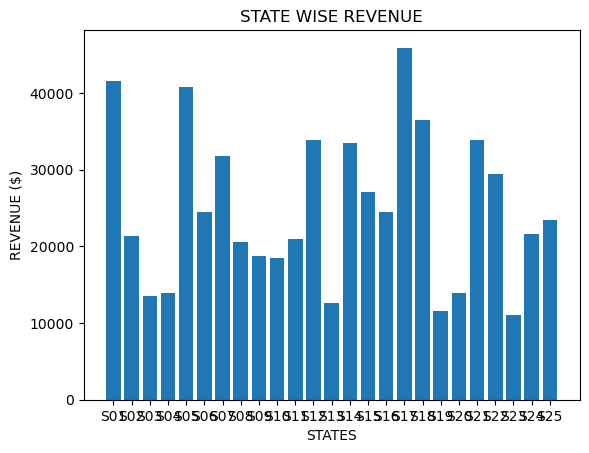

```python
# creating bar chart
plt.bar(med_summary['STATE_CODE'], med_summary['REVENUE'])

# adding labels
plt.xlabel('STATES')
plt.ylabel('REVENUE ($)')
plt.title('STATE WISE REVENUE')

# display the chart
plt.show()
```

### 📝 Purpose:

To visualize revenue distribution across different states and identify which ones contribute the most.

### 📘 Explanation:

- `plt.bar(...)` creates a vertical bar chart.
- `med_summary['STATE_CODE']` is used for the **x-axis** (state identifiers).
- `med_summary['REVENUE']` is used for the **y-axis** (revenue generated).
- The chart helps in identifying **high-revenue states** compared to others.

# 📝 Visualization Assignment: Pie Chart

### Question:

Create a pie chart to visualize the percentage distribution of subscribers across states from the `med_summary` DataFrame.

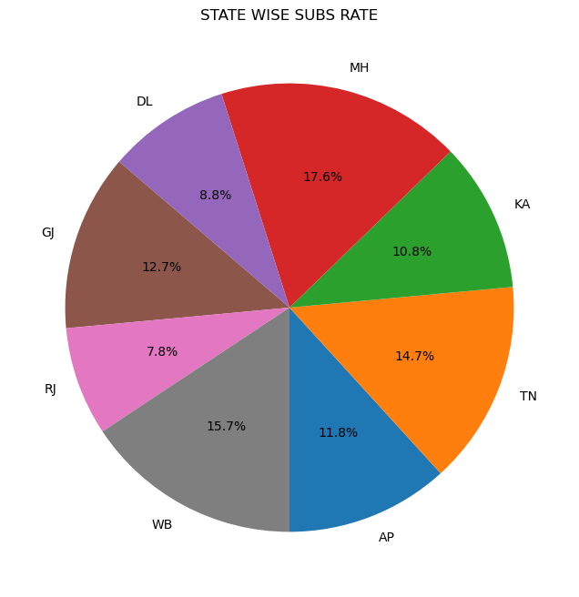

```python
import pandas as pd
import matplotlib.pyplot as plt

# Sample dataset
data = {
    'STATE_CODE': ['AP', 'TN', 'KA', 'MH', 'DL', 'GJ', 'RJ', 'WB'],
    'SUBS': [1200, 1500, 1100, 1800, 900, 1300, 800, 1600]
}

med_summary = pd.DataFrame(data)

# preparing values
STATES = med_summary['STATE_CODE']
SUBS = med_summary['SUBS']

# creating pie chart
plt.figure(figsize=(8, 8))  # Set the figure size
plt.pie(SUBS, labels=STATES, autopct='%1.1f%%', startangle=270)

# Add a title
plt.title('STATE WISE SUBS RATE')

# display the chart
plt.show()
```

### ✅ Purpose:

To create a pie chart showing the percentage distribution of subscribers per state.

### 📝 Explanation:

- `plt.figure(figsize=(8, 8))` sets the figure size for better visualization.
- `plt.pie(...)` creates a pie chart.
- `labels=STATES` displays state codes on the chart.
- `autopct='%1.1f%%'` shows percentages on each slice.
- `startangle=270` rotates the chart for a better layout.
- `plt.title(...)` adds a descriptive title.

Here’s the **formatted assignment version** for your given code with the proper title format and `figsize` inserted as you requested:

# 📝 Visualization Assignment: Pie Chart with Explode

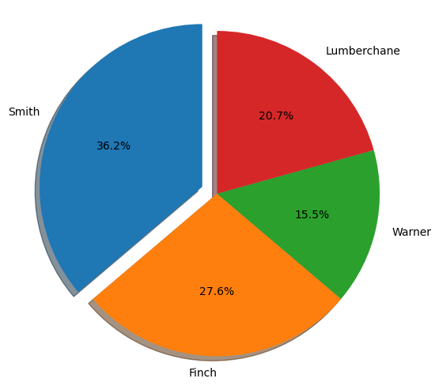

```python
import pandas as pd
from matplotlib import pyplot as plt

# Step 1: Create a DataFrame
data = {'Player': ['Smith', 'Finch', 'Warner', 'Lumberchane'],
        'Runs': [42, 32, 18, 24]}

df = pd.DataFrame(data)

# Step 2: Extract Data from DataFrame
Aus_Players = df['Player']
Runs = df['Runs']

# Step 3: Pie chart creation
explode = (0.1, 0, 0, 0)  # Explode the 1st slice to highlight it

fig1, ax1 = plt.subplots(figsize=(6,6))  # Added figsize
ax1.pie(Runs, explode=explode, labels=Aus_Players, autopct='%1.1f%%',
        shadow=True, startangle=90)

ax1.axis('equal')  # Equal aspect ratio ensures that pie is drawn as a circle.

# Step 4: Show plot
plt.show()
```

# 📝 Visualization Assignment: Line Chart

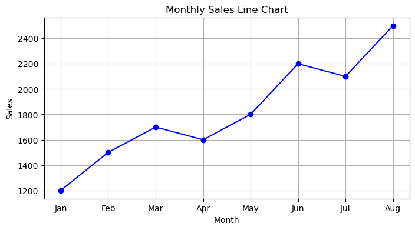

```python
import pandas as pd
import matplotlib.pyplot as plt

# Step 1: Create a NEW dataset (Monthly Sales Example)
data = {
    'MONTH': ['Jan', 'Feb', 'Mar', 'Apr', 'May', 'Jun', 'Jul', 'Aug'],
    'SALES': [1200, 1500, 1700, 1600, 1800, 2200, 2100, 2500]
}

sales_summary = pd.DataFrame(data)

# Step 2: Create a line chart
plt.figure(figsize=(8, 4))  # Set the figure size
plt.plot(sales_summary['MONTH'], sales_summary['SALES'], marker='o', linestyle='-', color='b')

# Step 3: Add labels and title
plt.xlabel('Month')
plt.ylabel('Sales')
plt.title('Monthly Sales Line Chart')

# Step 4: Display the chart
plt.grid(True)  # Add grid lines
plt.show()
```

# 📝 Visualization Assignment: Dynamic Bar Chart

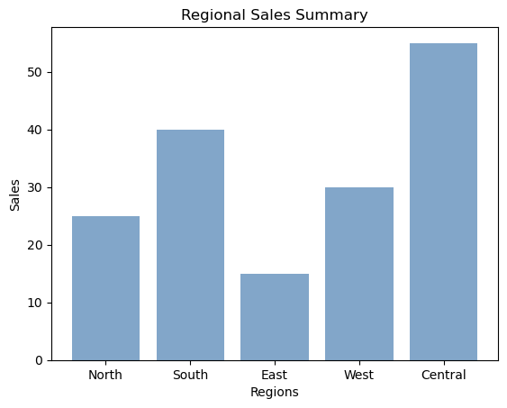

```python
import matplotlib.pyplot as plt
import pandas as pd

# New dataset: Sales in regions
sales = [25, 40, 15, 30, 55]
regions = ('North', 'South', 'East', 'West', 'Central')

df = pd.DataFrame({'sales': sales,
                   'regions': regions})

# Define one RGBA color for all bars
color = (0.3,  # redness
         0.5,  # greenness
         0.7,  # blueness
         0.7   # transparency
         )

# Create bars
fig, ax = plt.subplots()
ax.bar(df['regions'], df['sales'],
       color=color)

# Add labels
plt.xlabel("Regions")
plt.ylabel("Sales")
plt.title("Regional Sales Summary")

# Show graph
plt.show()
```

# 📝 Assignment: Radar Chart with Custom Parameters

### Dataset & Code

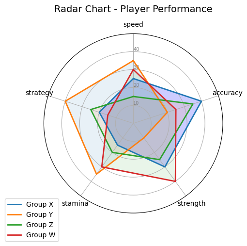

```python
# Libraries
import matplotlib.pyplot as plt
import pandas as pd
from math import pi

# New dataset
df = pd.DataFrame({
    'group': ['X','Y','Z','W'],
    'speed': [25, 35, 15, 30],
    'accuracy': [40, 20, 35, 25],
    'strength': [30, 10, 25, 40],
    'stamina': [15, 35, 20, 30],
    'strategy': [20, 40, 25, 15]
})

#  ---- PART 1: Create background
categories = list(df)[1:]   # variable names
N = len(categories)

# Angle calculation
angles = [n / float(N) * 2 * pi for n in range(N)]
angles += angles[:1]

# Initialise radar chart
ax = plt.subplot(111, polar=True)

# Question: Why do we set offset and direction here?
ax.set_theta_offset(pi / 2)       # places first axis at the top
ax.set_theta_direction(-1)        # clockwise

# Add labels
plt.xticks(angles[:-1], categories)

# Question: What happens if we change ticks and limits?
ax.set_rlabel_position(0)
plt.yticks([10,20,30,40], ["10","20","30","40"], color="grey", size=7)
plt.ylim(0,50)   # setting limit higher than max to give padding

# ------- PART 2: Plot data
values = df.loc[0].drop('group').values.flatten().tolist()
values += values[:1]
ax.plot(angles, values, linewidth=2, linestyle='solid', label="Group X")
ax.fill(angles, values, 'b', alpha=0.2)

# Add more groups for comparison
for i in range(1, len(df)):
    values = df.loc[i].drop('group').values.flatten().tolist()
    values += values[:1]
    ax.plot(angles, values, linewidth=2, linestyle='solid', label=f"Group {df.loc[i,'group']}")
    ax.fill(angles, values, alpha=0.1)

# Add title and legend
plt.title("Radar Chart - Player Performance", size=14, y=1.1)
plt.legend(loc='upper right', bbox_to_anchor=(0.1,0.1))

plt.show()
```

### ❓ Questions

1. What does `ax.set_theta_offset(pi / 2)` do?
   - (a) Starts first axis at the top
   - (b) Rotates chart by 180°
   - (c) Removes axis labels
   - (d) Sets axis spacing
2. What happens if we change `ax.set_theta_direction(-1)` to `1`?
   - (a) Plot is drawn clockwise
   - (b) Plot is drawn counter-clockwise
   - (c) Nothing changes
   - (d) Y-axis labels disappear
3. Why do we set `plt.ylim(0,50)` even though data max is 40?
   - (a) To hide outliers
   - (b) To add padding space in chart
   - (c) To normalize values
   - (d) To shift labels

Here’s the **Visualization Assignment** version for your **Donut Chart** example, with questions on parameters and full code included:

# 📝 Visualization Assignment: Donut Chart

### Questions:

1. What is the use of the parameter `plt.Circle((0,0), 0.7, color='white')` in this chart?
2. How does changing the radius (e.g., `0.7`) affect the appearance of the donut hole?
3. Which parameter of `plt.pie()` can be used to show percentage values inside the chart?
4. What is the purpose of `plt.gcf().gca().add_artist(my_circle)` in this code?

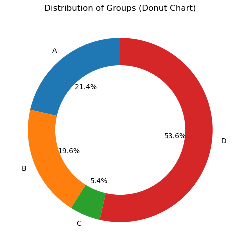

```python
# Libraries
import matplotlib.pyplot as plt

# Create data
size_of_groups = [12, 11, 3, 30]

# Create a figure with specific size
plt.figure(figsize=(6, 6))  # sets chart dimensions

# Create a pie plot
plt.pie(size_of_groups, labels=["A", "B", "C", "D"], autopct='%1.1f%%', startangle=90)

# Add a circle at the center to transform it into a donut chart
my_circle = plt.Circle((0, 0), 0.7, color='white')  # center hole with radius 0.7
p = plt.gcf()  # get current figure
p.gca().add_artist(my_circle)  # add the circle to the plot

# Add title
plt.title("Distribution of Groups (Donut Chart)")

# Show the chart
plt.show()
```

Got it 👍 I’ll create a **new dataset**, update the **stacked bar chart code**, and then write **assignment questions + answers in your format**.

Here’s the full code + Q&A:

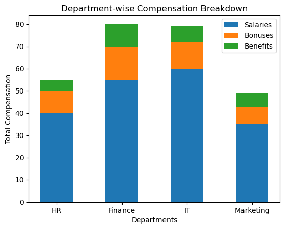

```python
# 📊 Visualization with Stacked Bar Chart

import numpy as np
import matplotlib.pyplot as plt

# Step 1: Define categories and values for each bar segment
departments = ['HR', 'Finance', 'IT', 'Marketing']

salaries = [40, 55, 60, 35]   # Base salary component
bonuses = [10, 15, 12, 8]     # Bonus component
benefits = [5, 10, 7, 6]      # Benefits component

# Step 2: Set width of each bar and compute x-axis positions
bar_width = 0.5
index = np.arange(len(departments))

# Step 3: Plot salaries (bottom stack)
plt.bar(index, salaries, bar_width, label='Salaries')

# Step 4: Plot bonuses on top of salaries
plt.bar(index, bonuses, bar_width, bottom=salaries, label='Bonuses')

# Step 5: Plot benefits on top of (salaries + bonuses)
plt.bar(index, benefits, bar_width,
        bottom=np.array(salaries) + np.array(bonuses),
        label='Benefits')

# Step 6: Customize chart
plt.xlabel('Departments')
plt.ylabel('Total Compensation')
plt.title('Department-wise Compensation Breakdown')
plt.xticks(index, departments)
plt.legend()

# Step 7: Show chart
plt.show()
```

# 📝 Assignment: Stacked Bar Chart

### **Q1.**

Plot the stacked bar chart for the given data of **departments** with `salaries`, `bonuses`, and `benefits`. Which department has the **highest total compensation**?

✅ **Answer:**

- HR → 40 + 10 + 5 = **55**
- Finance → 55 + 15 + 10 = **80**
- IT → 60 + 12 + 7 = **79**
- Marketing → 35 + 8 + 6 = **49**

👉 **Finance has the highest total compensation (80).**

### **Q2.**

Modify the chart to **exclude bonuses** and only plot **salaries + benefits**. Which department now has the **lowest compensation**?

✅ **Answer:**

- HR → 40 + 5 = **45**
- Finance → 55 + 10 = **65**
- IT → 60 + 7 = **67**
- Marketing → 35 + 6 = **41**

👉 **Marketing has the lowest compensation (41).**

Here’s a **fresh dataset** with the same **scatterplot assignment** format, including both **Matplotlib** and **Seaborn** plots, along with **assignment question + solution** in your style:

# 📝 Assignment: Scatter Plot Visualization

### **Q1.**

Create a scatter plot using **Matplotlib** and **Seaborn** for the following dataset. Use different colors for categories in Seaborn.

```python
# Step 1: Import necessary libraries
import pandas as pd
import matplotlib.pyplot as plt
import seaborn as sns

# Step 2: Create a NEW dataset
data = {
    'X': [10, 15, 8, 20, 5, 18, 12, 25, 7, 14],
    'Y': [50, 60, 45, 70, 40, 65, 55, 80, 42, 58],
    'Category': ['Red', 'Blue', 'Red', 'Blue', 'Red', 'Blue', 'Red', 'Blue', 'Red', 'Blue']
}

df = pd.DataFrame(data)
```

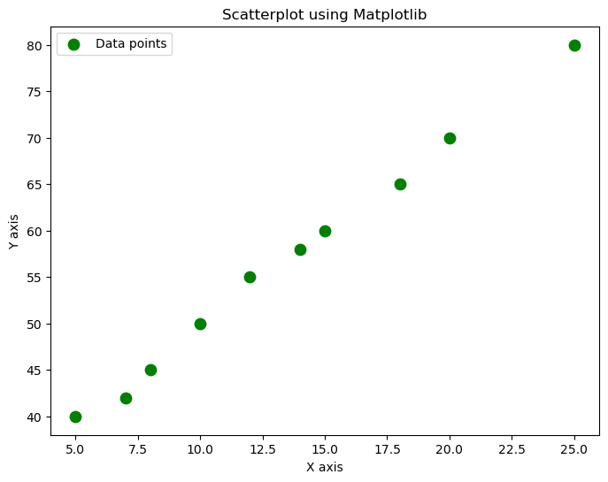

```python
# Step 3: Scatterplot using Matplotlib
plt.figure(figsize=(8, 6))
plt.scatter(df['X'], df['Y'], c='green', label='Data points', s=80)
plt.title('Scatterplot using Matplotlib')
plt.xlabel('X axis')
plt.ylabel('Y axis')
plt.legend()
plt.show()
```

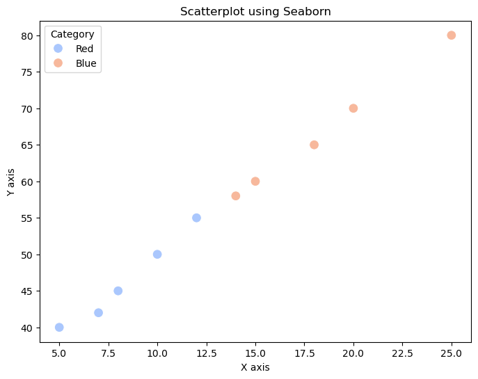

```python
# Step 4: Scatterplot using Seaborn
plt.figure(figsize=(8, 6))
sns.scatterplot(x='X', y='Y', hue='Category', data=df, palette='coolwarm', s=100)
plt.title('Scatterplot using Seaborn')
plt.xlabel('X axis')
plt.ylabel('Y axis')
plt.show()
```

### ✅ Solution / Explanation

1. **Matplotlib Scatterplot**
   - `plt.scatter(df['X'], df['Y'], c='green', s=80)` plots all points in **green** with size 80.
   - `plt.legend()` adds a label.
   - `plt.title()`, `plt.xlabel()`, `plt.ylabel()` label the chart.
2. **Seaborn Scatterplot**
   - `sns.scatterplot(x='X', y='Y', hue='Category', data=df, palette='coolwarm', s=100)` automatically colors points by `Category`.
   - `s=100` controls marker size.
   - `palette='coolwarm'` provides a visually distinct color mapping for categories.
3. **Observation / Insight**
   - Points can be visually distinguished based on the `Category` variable.
   - Matplotlib requires manual coloring, while Seaborn provides **automatic hue mapping** for categorical variables.

# 📝 Assignment: Bubble Chart Visualization

### **Q1.**

Create a bubble chart using Matplotlib for the given dataset. Use `X` for x-axis, `Y` for y-axis, and `Size` for bubble sizes. Include a legend showing the bubble size scale.

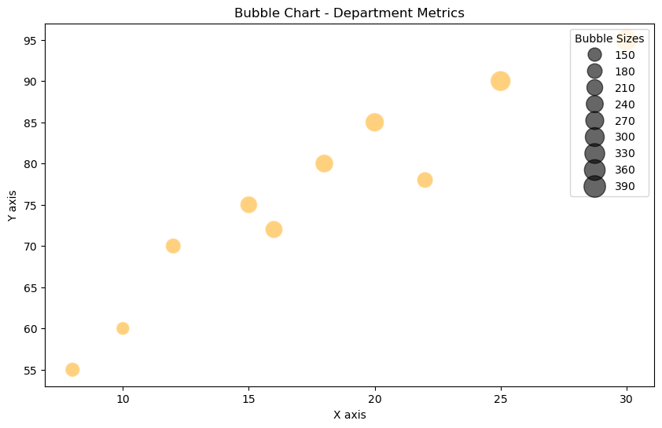

```python
# Step 1: Import necessary libraries
import pandas as pd
import matplotlib.pyplot as plt

# Step 2: Create a NEW dataset
data = {
    'X': [10, 15, 12, 20, 8, 25, 18, 30, 22, 16],  # X-axis values
    'Y': [60, 75, 70, 85, 55, 90, 80, 95, 78, 72], # Y-axis values
    'Size': [150, 250, 200, 300, 180, 350, 280, 400, 220, 260],  # Bubble sizes
    'Category': ['Red', 'Blue', 'Red', 'Blue', 'Red', 'Blue', 'Red', 'Blue', 'Red', 'Blue']
}

# Convert to DataFrame
df = pd.DataFrame(data)

# Step 3: Plot the bubble chart
plt.figure(figsize=(10, 6))

scatter = plt.scatter(
    df['X'], df['Y'],
    s=df['Size'],          # Bubble sizes
    alpha=0.5,             # Semi-transparent
    c='orange',            # Bubble color
    edgecolors='w',        # White edge
    label='Data points'
)

# Add title and labels
plt.title('Bubble Chart - Department Metrics')
plt.xlabel('X axis')
plt.ylabel('Y axis')

# Add legend for bubble sizes
handles, labels = scatter.legend_elements(prop='sizes', alpha=0.6)
plt.legend(handles, labels, loc="upper right", title="Bubble Sizes")

# Show plot
plt.show()
```

### ✅ Solution / Explanation

1. **DataFrame creation**
   - `df = pd.DataFrame(data)` creates a tabular structure for plotting.
2. **Bubble Chart using Matplotlib**
   - `s=df['Size']` → controls bubble area according to the `Size` column.
   - `alpha=0.5` → makes bubbles semi-transparent.
   - `c='orange'` → sets bubble color.
   - `edgecolors='w'` → adds a white border for better visibility.
3. **Legend for bubble sizes**
   - `scatter.legend_elements(prop='sizes', alpha=0.6)` automatically generates bubble-size legend.
   - `plt.legend()` displays the legend on the chart.
4. **Observation / Insight**
   - Larger bubbles represent higher values in the `Size` column.
   - Plot provides a visual representation of **X vs Y metrics with magnitude** indicated by bubble size.

Here’s a **new dataset** and a **complete assignment version** for your **histogram example**, including **Matplotlib and Seaborn**, with explanation in your format:

# 📝 Assignment: Histogram Visualization

### **Q1.**

Create a histogram to visualize the distribution of the dataset using **Matplotlib** and **Seaborn**. Use appropriate bins and colors, and add a **KDE curve** in Seaborn.

```python
# Step 1: Import libraries
import pandas as pd
import matplotlib.pyplot as plt
import seaborn as sns

# Step 2: Create a NEW dataset
data = {
    'Values': [15, 20, 25, 18, 30, 22, 40, 35, 28, 32, 45, 38, 50, 42, 60, 55, 48, 70, 65, 58]
}

df = pd.DataFrame(data)
```

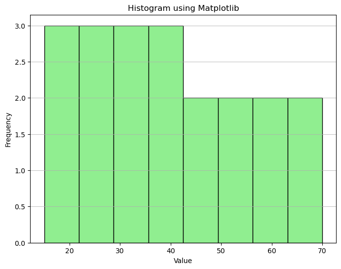

```python
# Step 3: Plot histogram using Matplotlib
plt.figure(figsize=(8, 6))
plt.hist(df['Values'], bins=8, color='lightgreen', edgecolor='black')
plt.title('Histogram using Matplotlib')
plt.xlabel('Value')
plt.ylabel('Frequency')
plt.grid(axis='y', alpha=0.75)
plt.show()
```

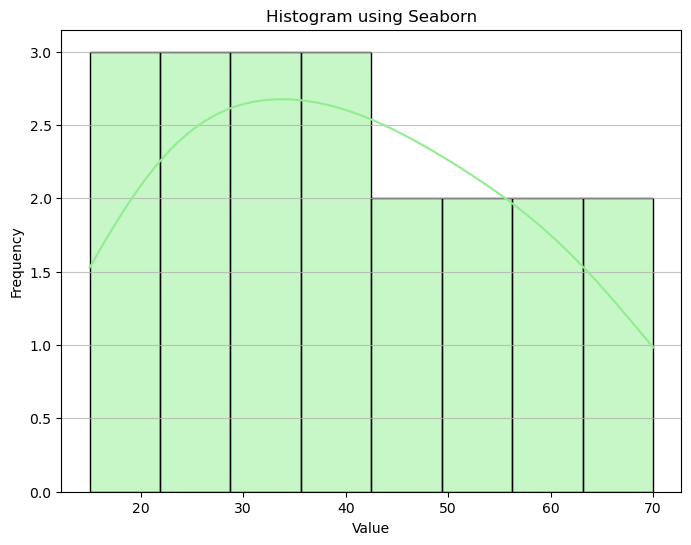

```python
# Step 4: Plot histogram using Seaborn
plt.figure(figsize=(8, 6))
sns.histplot(df['Values'], bins=8, kde=True, color='lightgreen')
plt.title('Histogram using Seaborn')
plt.xlabel('Value')
plt.ylabel('Frequency')
plt.grid(axis='y', alpha=0.75)
plt.show()
```

### ✅ Solution / Explanation

1. **Matplotlib Histogram**
   - `plt.hist(df['Values'], bins=8, color='lightgreen', edgecolor='black')` divides the data into 8 equal-width intervals.
   - `color='lightgreen'` fills the bars.
   - `edgecolor='black'` outlines each bar.
   - `plt.grid(axis='y', alpha=0.75)` adds horizontal grid lines.
2. **Seaborn Histogram**
   - `sns.histplot(df['Values'], bins=8, kde=True, color='lightgreen')` adds a **KDE curve** showing the density estimate.
   - Automatically colors bars according to the `color` parameter.
3. **Purpose / Insight**
   - Both charts **show the frequency distribution** of numerical values.
   - Helps identify **concentration, spread, and skewness** in the dataset.

# 📝 Assignment: Box Plot Visualization

### **Q1.**

Create a box plot using **Matplotlib** to visualize the distribution of values for each category in the dataset. Customize the box color and add grid lines for clarity.

```python
# Step 1: Import libraries
import pandas as pd
import matplotlib.pyplot as plt

# Step 2: Create a NEW dataset
data = {
    'Category': ['X', 'X', 'X', 'X', 'X',
                 'Y', 'Y', 'Y', 'Y', 'Y',
                 'Z', 'Z', 'Z', 'Z', 'Z'],
    'Values': [12, 15, 14, 13, 16,
               22, 25, 23, 21, 24,
               35, 38, 36, 37, 34]
}

df = pd.DataFrame(data)
```

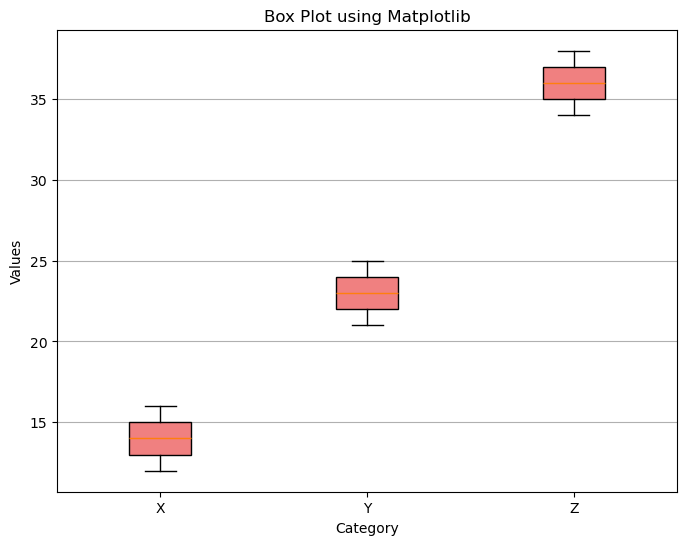

```python
# Step 3: Box plot using Matplotlib
plt.figure(figsize=(8, 6))
plt.boxplot([df[df['Category'] == 'X']['Values'],
             df[df['Category'] == 'Y']['Values'],
             df[df['Category'] == 'Z']['Values']],
            labels=['X', 'Y', 'Z'],
            patch_artist=True,
            boxprops=dict(facecolor='lightcoral'))
plt.title('Box Plot using Matplotlib')
plt.xlabel('Category')
plt.ylabel('Values')
plt.grid(axis='y')
plt.show()
```

### ✅ Solution / Explanation

1. **DataFrame creation**
   - `df = pd.DataFrame(data)` stores the data in a tabular format.
   - `Category` distinguishes groups, `Values` contains numerical data.
2. **Box Plot using Matplotlib**
   - `plt.boxplot([...], labels=['X','Y','Z'], patch_artist=True, boxprops=dict(facecolor='lightcoral'))`
     - `patch_artist=True` allows filling boxes with color.
     - `boxprops=dict(facecolor='lightcoral')` sets the box color.
   - Each list inside `plt.boxplot()` corresponds to one category.
3. **Grid and labels**
   - `plt.grid(axis='y')` adds horizontal grid lines.
   - `plt.title()`, `plt.xlabel()`, `plt.ylabel()` label the plot.
4. **Purpose / Insight**
   - Box plots visualize **median, quartiles, range, and potential outliers** for each category.
   - Helps compare the distribution between different groups.

# 📝 Assignment: Line Chart Visualization

### **Q1.**

Create a line chart to compare two variables over time using both **Matplotlib** and **Seaborn**. Include markers at each point, rotate x-axis labels for better readability, and add a legend.

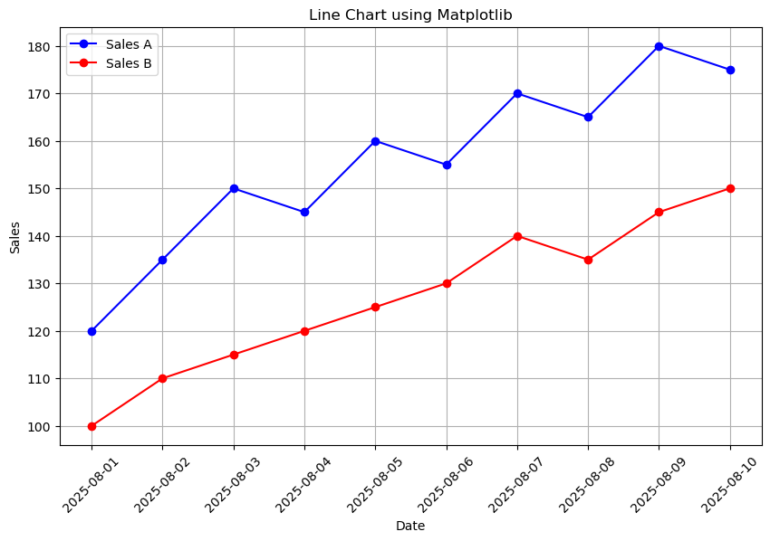

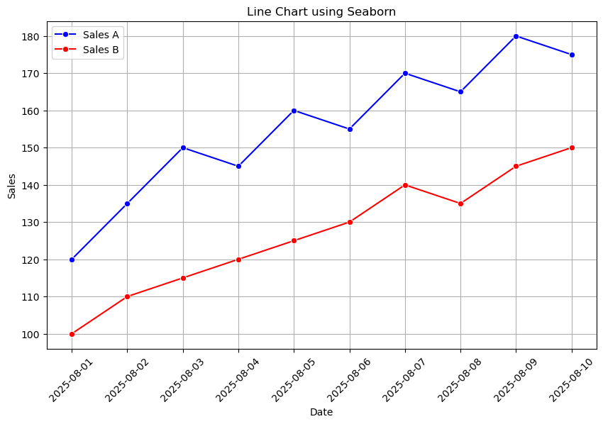

```python
# Step 1: Import necessary libraries
import pandas as pd
import matplotlib.pyplot as plt
import seaborn as sns

# Step 2: Create a NEW dataset
data = {
    'Date': pd.date_range(start='2025-08-01', periods=10, freq='D'),
    'Sales_A': [120, 135, 150, 145, 160, 155, 170, 165, 180, 175],
    'Sales_B': [100, 110, 115, 120, 125, 130, 140, 135, 145, 150]
}

df = pd.DataFrame(data)

# Step 3: Line chart using Matplotlib
plt.figure(figsize=(10, 6))
plt.plot(df['Date'], df['Sales_A'], marker='o', linestyle='-', color='b', label='Sales A')
plt.plot(df['Date'], df['Sales_B'], marker='o', linestyle='-', color='r', label='Sales B')
plt.title('Line Chart using Matplotlib')
plt.xlabel('Date')
plt.ylabel('Sales')
plt.xticks(rotation=45)
plt.legend()
plt.grid(True)
plt.show()

# Step 4: Line chart using Seaborn
plt.figure(figsize=(10, 6))
sns.lineplot(x='Date', y='Sales_A', data=df, marker='o', color='b', label='Sales A')
sns.lineplot(x='Date', y='Sales_B', data=df, marker='o', color='r', label='Sales B')
plt.title('Line Chart using Seaborn')
plt.xlabel('Date')
plt.ylabel('Sales')
plt.xticks(rotation=45)
plt.grid(True)
plt.show()
```

### ✅ Solution / Explanation

1. **DataFrame creation**
   - `df = pd.DataFrame(data)` stores the time series data.
   - `Date` column represents time; `Sales_A` and `Sales_B` are numerical values.
2. **Matplotlib line chart**
   - `plt.plot()` draws lines connecting data points with markers (`marker='o'`).
   - `linestyle='-'` connects points with lines.
   - `color` differentiates the two lines.
   - `plt.legend()` labels the lines.
   - `plt.xticks(rotation=45)` improves readability of date labels.
3. **Seaborn line chart**
   - `sns.lineplot()` plots each series with markers.
   - Automatically handles legends and aesthetics.
4. **Purpose / Insight**
   - Line charts visualize **trends over time**.
   - Comparison of two series shows which variable grows faster or has higher values over the same period.

# 📝 Assignment: Heatmap Visualization

### **Q1.**

Create a heatmap using Seaborn for weekly performance data. Annotate each cell, customize the color map, and include grid lines.

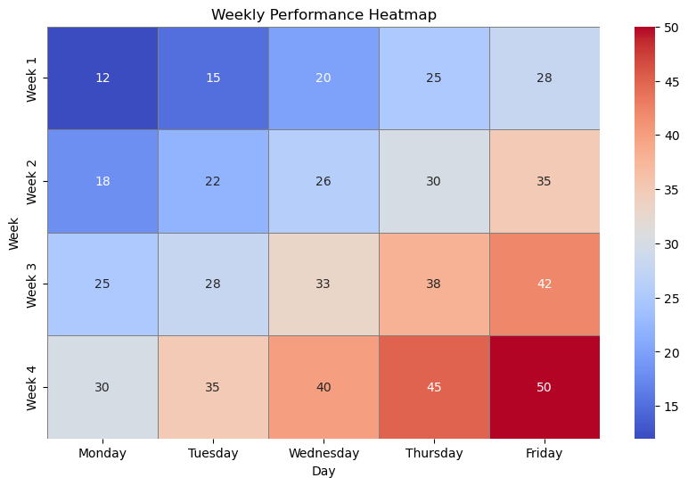

```python
# Step 1: Import libraries
import pandas as pd
import seaborn as sns
import matplotlib.pyplot as plt

# Step 2: Create a NEW dataset
data = {
    'Monday': [12, 18, 25, 30],
    'Tuesday': [15, 22, 28, 35],
    'Wednesday': [20, 26, 33, 40],
    'Thursday': [25, 30, 38, 45],
    'Friday': [28, 35, 42, 50]
}

index = ['Week 1', 'Week 2', 'Week 3', 'Week 4']
df = pd.DataFrame(data, index=index)

# Step 3: Plot heatmap using Seaborn
plt.figure(figsize=(10, 6))
sns.heatmap(df, annot=True, cmap='coolwarm', linewidths=.5, linecolor='gray')
plt.title('Weekly Performance Heatmap')
plt.xlabel('Day')
plt.ylabel('Week')
plt.show()
```

### ✅ Solution / Explanation

1. **DataFrame creation**
   - `df = pd.DataFrame(data, index=index)` stores weekly performance values.
   - Rows represent weeks; columns represent weekdays.
2. **Seaborn heatmap**
   - `sns.heatmap(df, annot=True, cmap='coolwarm', linewidths=.5, linecolor='gray')`
     - `annot=True` adds the numerical values in each cell.
     - `cmap='coolwarm'` provides a visually distinct gradient.
     - `linewidths=.5` and `linecolor='gray'` draw grid lines between cells.
3. **Purpose / Insight**
   - Heatmaps visualize **patterns, trends, and differences** across categories.
   - Allows quick identification of higher and lower values for weekdays across weeks.